# AnnotationsPart3StatisticsandRegression

Michael K. Jones

2025-07-05

```r
library(data.table)
merged <- fread("/Users/mikej/Documents/Career/Georges/Ule/intron_retention_propensity/data/VastDB/IntronRetentionPredictionsAnnotated13082025.tsv")
#predict100 <- fread("/Users/mikej/Documents/Career/Georges/Ule/intron_retention_propensity/data/IR/DecoySpliceSites_f100.bed")
#predict50 <- fread("/Users/mikej/Documents/Career/Georges/Ule/intron_retention_propensity/data/IR/DecoySpliceSites_f50.bed")
#splice250 <- fread("/Users/mikej/Documents/Career/Georges/Ule/intron_retention_propensity/data/IR/NonPRPF8SpliceSites_f250.bed")
#splice100 <- fread("/Users/mikej/Documents/Career/Georges/Ule/intron_retention_propensity/data/IR/NonPRPF8SpliceSites_f100.bed")
```

## Transposon linear regression analysis

```r
library(tidyverse)
# Step 1: Select all *_PSI columns and compute row means
psi_cols <- grep("_PSI$", colnames(merged), value = TRUE)

merged$mean_PSI <- rowMeans(merged[, ..psi_cols], na.rm = TRUE)

# Step 2: Binary transposon presence
trans_binary <- merged[, 66:74] %>%
  mutate(across(everything(), ~ ifelse(is.na(.) | . == "", 0, 1)))

# Rename illegal column name
colnames(trans_binary)[colnames(trans_binary) == "Retroposon/SVA"] <- "Retroposon_SVA"

# Step 3: Combine into model input
merged_for_lm <- bind_cols(mean_PSI = merged$mean_PSI, trans_binary) %>%
  drop_na(mean_PSI)

# Step 4: Linear regression
model_lm <- lm(mean_PSI ~ sine + line + dna + ltr + Retroposon_SVA +
                          satellite + Low_complexity + Simple_repeat + rna,
               data = merged_for_lm)

summary(model_lm)
```

```
##
## Call:
## lm(formula = mean_PSI ~ sine + line + dna + ltr + Retroposon_SVA +
##     satellite + Low_complexity + Simple_repeat + rna, data = merged_for_lm)
##
## Residuals:
##     Min      1Q  Median      3Q     Max
## -20.519  -6.099  -3.461   1.053  94.497
##
## Coefficients:
##                Estimate Std. Error t value Pr(>|t|)
## (Intercept)     6.72678    0.05416 124.197  < 2e-16 ***
## sine           -0.32183    0.08324  -3.866 0.000111 ***
## line           -0.44314    0.08610  -5.147 2.66e-07 ***
## dna            -0.38985    0.08698  -4.482 7.39e-06 ***
## ltr            -0.07767    0.09673  -0.803 0.422037
## Retroposon_SVA  2.45223    0.32511   7.543 4.62e-14 ***
## satellite       1.66161    0.77813   2.135 0.032729 *
## Low_complexity  0.40125    0.10871   3.691 0.000223 ***
## Simple_repeat   0.17260    0.08191   2.107 0.035096 *
## rna             1.26877    0.22300   5.689 1.28e-08 ***
## ---
## Signif. codes:  0 '***' 0.001 '**' 0.01 '*' 0.05 '.' 0.1 ' ' 1
##
## Residual standard error: 14.64 on 192774 degrees of freedom
## Multiple R-squared:  0.00116,    Adjusted R-squared:  0.001114
## F-statistic: 24.88 on 9 and 192774 DF,  p-value: < 2.2e-16
```

## Binarise PSI values at a threshold of 10%

```r
# Binarise PSI values
psi_mat <- as.data.frame(merged[, 75:219])
psi_mat[] <- lapply(psi_mat, function(x) as.numeric(as.character(x)))
psi_bin <- as.data.frame(lapply(psi_mat, function(x) ifelse(is.na(x), 0, ifelse(x >= 10, 1, 0))))
psi_binarised_total <- rowSums(psi_bin, na.rm = TRUE)
merged$psi_binarised_total <- psi_binarised_total
```

## Create histogram of all prediction overlap sum values and determine boundary of 95% confidence interval

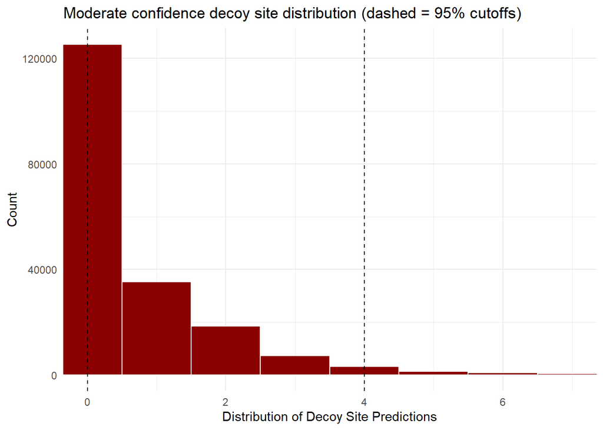

```r
# plot of PRPF8 + splice sites distribution when intersected with f100 model (moderate conf)

q <- quantile(merged$DecoySiteModerateConf, c(0.025, 0.975), na.rm = TRUE)

ggplot(merged, aes(x = DecoySiteModerateConf)) +
  geom_histogram(binwidth = 1, colour = "white", fill = "darkred") +
  geom_vline(xintercept = q, linetype = "dashed") +
  labs(x = "Distribution of Decoy Site Predictions",
       y = "Count",
       title = "Moderate confidence decoy site distribution (dashed = 95% cutoffs)") +
  theme_minimal() +
  coord_cartesian(xlim = c(0, 7))
```

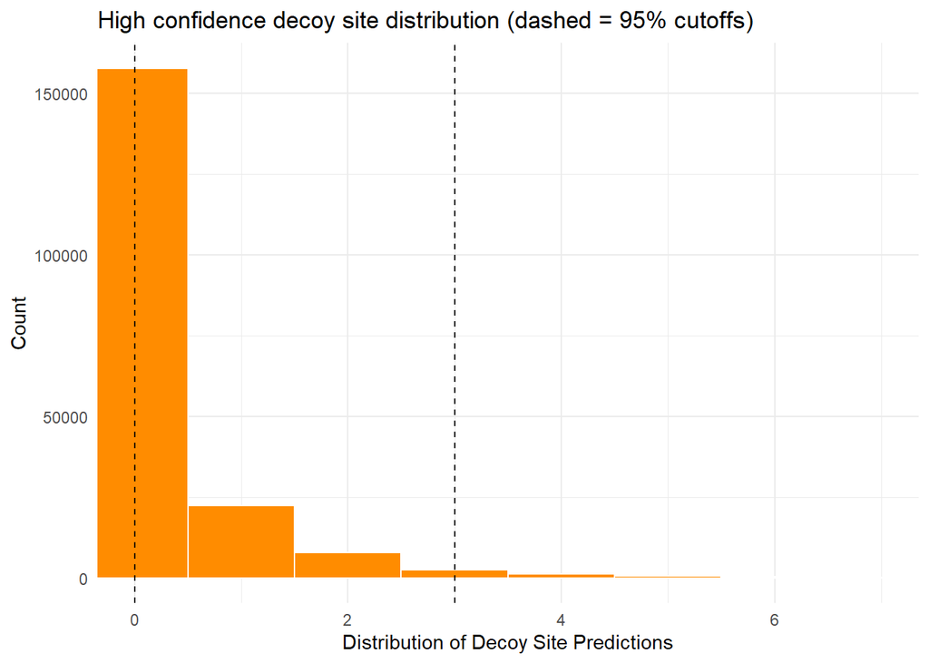

```r
# plot of PRPF8 + splice sites distribution when intersected with f50 model (high conf)

q2 <- quantile(merged$DecoySiteHighConf, c(0.025, 0.975), na.rm = TRUE)

ggplot(merged, aes(x = DecoySiteHighConf)) +
  geom_histogram(binwidth = 1, colour = "white", fill = "darkorange") +
  geom_vline(xintercept = q2, linetype = "dashed") +
  labs(x = "Distribution of Decoy Site Predictions",
       y = "Count",
       title = "High confidence decoy site distribution (dashed = 95% cutoffs)") +
  theme_minimal() +
  coord_cartesian(xlim = c(0, 7))
```

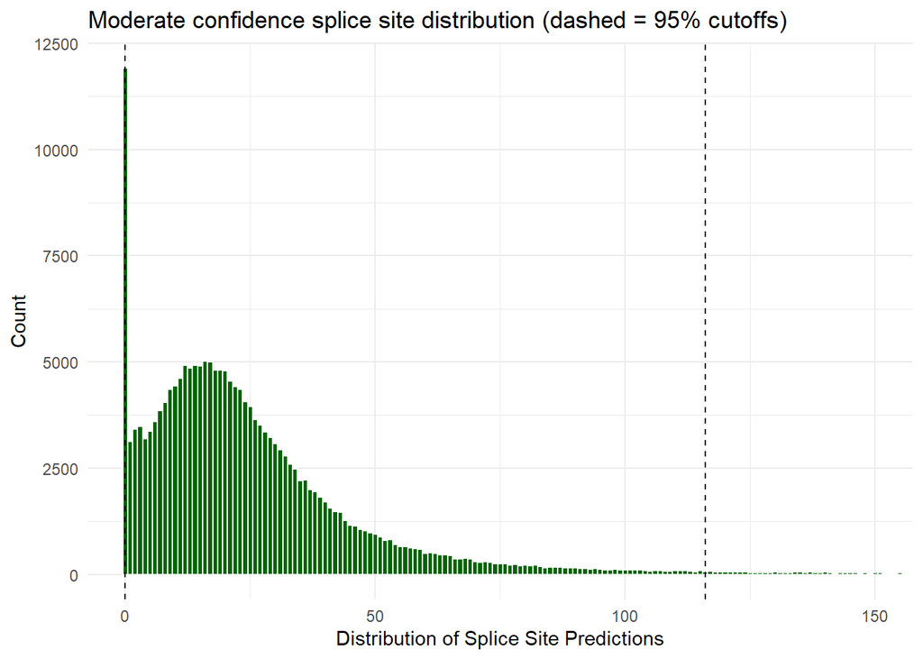

```r
# plot of non-PRPF8 overlapping splice sites when intersected with f100 model (moderate conf)

s <- quantile(merged$NonPRPF8SpliceCountModerateConf, c(0.025, 0.975), na.rm = TRUE)

ggplot(merged, aes(x = NonPRPF8SpliceCountModerateConf)) +
  geom_histogram(binwidth = 1, colour = "white", fill = "darkgreen") +
  geom_vline(xintercept = s, linetype = "dashed") +
  labs(x = "Distribution of Splice Site Predictions",
       y = "Count",
       title = "Moderate confidence splice site distribution (dashed = 95% cutoffs)") +
  theme_minimal() +
  coord_cartesian(xlim = c(0, 150))
```

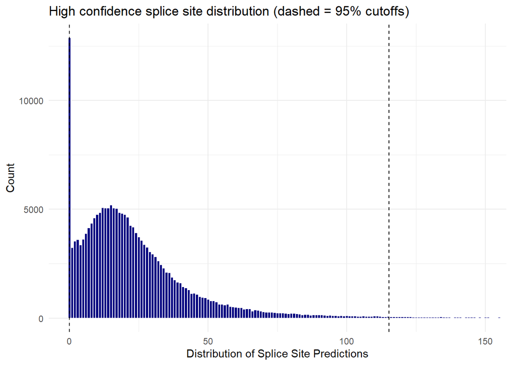

```r
# plot of non-PRPF8 overlapping splice sites when intersected with f250 model (high conf)

s2 <- quantile(merged$NonPRPF8SpliceCountHighConf, c(0.025, 0.975), na.rm = TRUE)

ggplot(merged, aes(x = NonPRPF8SpliceCountHighConf)) +
  geom_histogram(binwidth = 1, colour = "white", fill = "navy") +
  geom_vline(xintercept = s2, linetype = "dashed") +
  labs(x = "Distribution of Splice Site Predictions",
       y = "Count",
       title = "High confidence splice site distribution (dashed = 95% cutoffs)") +
  theme_minimal() +
  coord_cartesian(xlim = c(0, 150))
```

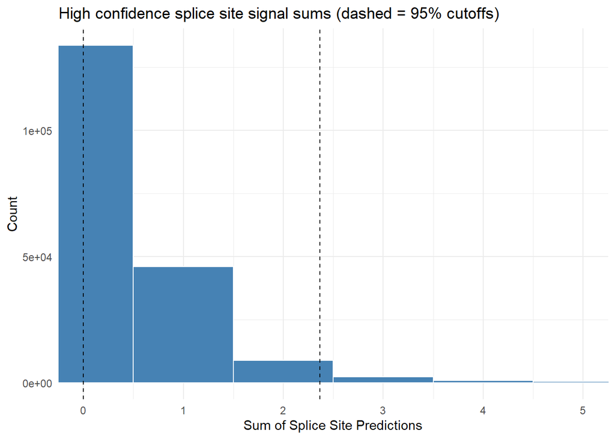

```r
# plot of non-PRPF8 overlapping splice sites signal sums when intersected with f250 model (high conf)

s3 <- quantile(merged$NonPRPF8SpliceSignalHighConf, c(0.025, 0.975), na.rm = TRUE)

ggplot(merged, aes(x = NonPRPF8SpliceSignalHighConf)) +
  geom_histogram(binwidth = 1, colour = "white", fill = "steelblue") +
  geom_vline(xintercept = s3, linetype = "dashed") +
  labs(x = "Sum of Splice Site Predictions",
       y = "Count",
       title = "High confidence splice site signal sums (dashed = 95% cutoffs)") +
  theme_minimal() +
  coord_cartesian(xlim = c(0, 5))
```

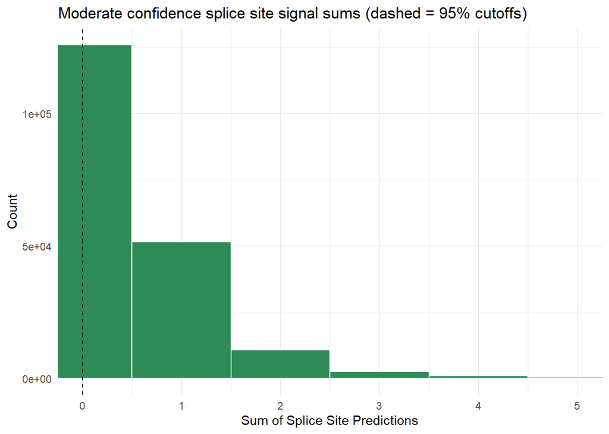

```r
# plot of non-PRPF8 overlapping splice sites signal sums when intersected with f100 model (moderate conf)

s4 <- quantile(merged$NonPRPF8SpliceCountModerateConf, c(0.025, 0.975), na.rm = TRUE)

ggplot(merged, aes(x = NonPRPF8SpliceSignalModerateConf)) +
  geom_histogram(binwidth = 1, colour = "white", fill = "seagreen") +
  geom_vline(xintercept = s4, linetype = "dashed") +
  labs(x = "Sum of Splice Site Predictions",
       y = "Count",
       title = "Moderate confidence splice site signal sums (dashed = 95% cutoffs)") +
  theme_minimal() +
  coord_cartesian(xlim = c(0, 5))
```

```r
library(patchwork)
library(scales)
```

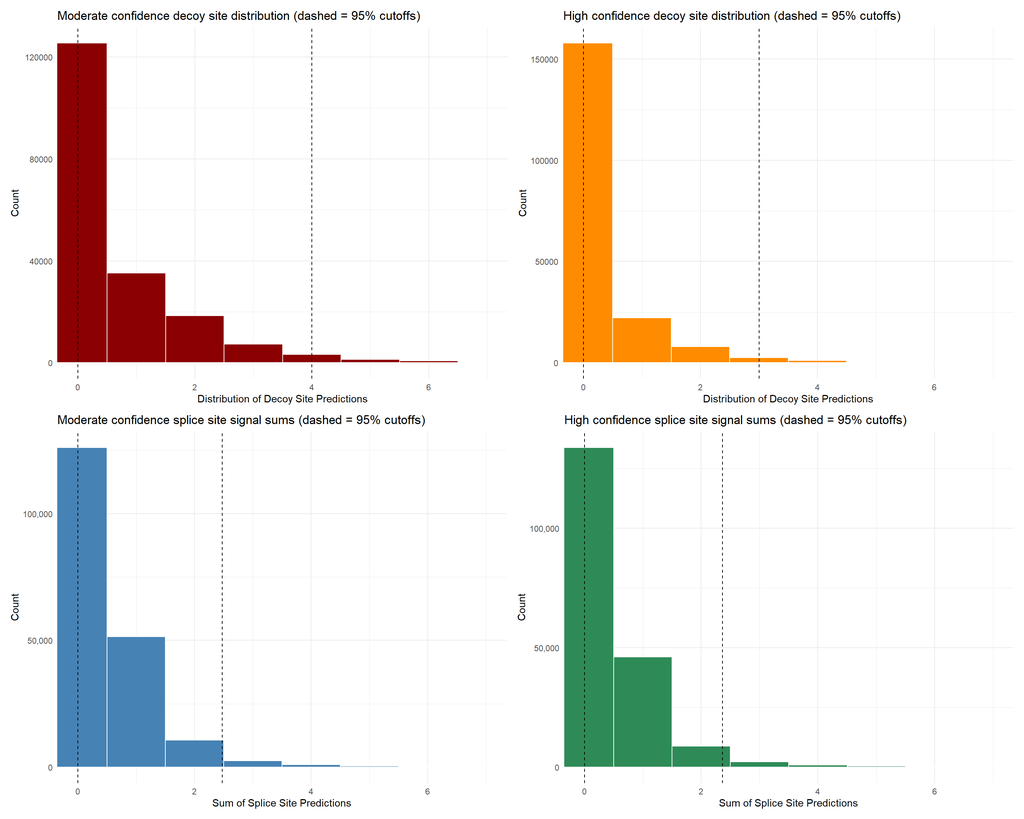

```r
# plot of PRPF8 + splice sites distribution when intersected with f100 model (moderate conf)
q <- quantile(merged$DecoySiteModerateConf, c(0.025, 0.975), na.rm = TRUE)
p1 <- ggplot(merged, aes(x = DecoySiteModerateConf)) +
  geom_histogram(binwidth = 1, colour = "white", fill = "darkred") +
  geom_vline(xintercept = q, linetype = "dashed") +
  labs(x = "Distribution of Decoy Site Predictions",
       y = "Count",
       title = "Moderate confidence decoy site distribution (dashed = 95% cutoffs)") +
  theme_minimal() +
  coord_cartesian(xlim = c(0, 7))

# plot of PRPF8 + splice sites distribution when intersected with f50 model (high conf)
q2 <- quantile(merged$DecoySiteHighConf, c(0.025, 0.975), na.rm = TRUE)
p2 <- ggplot(merged, aes(x = DecoySiteHighConf)) +
  geom_histogram(binwidth = 1, colour = "white", fill = "darkorange") +
  geom_vline(xintercept = q2, linetype = "dashed") +
  labs(x = "Distribution of Decoy Site Predictions",
       y = "Count",
       title = "High confidence decoy site distribution (dashed = 95% cutoffs)") +
  theme_minimal() +
  coord_cartesian(xlim = c(0, 7))

# plot of non-PRPF8 overlapping splice sites signal sums when intersected with f100 model (moderate conf)
s3 <- quantile(merged$NonPRPF8SpliceSignalModerateConf, c(0.025, 0.975), na.rm = TRUE)
p3 <- ggplot(merged, aes(x = NonPRPF8SpliceSignalModerateConf)) +
  geom_histogram(binwidth = 1, colour = "white", fill = "steelblue") +
  geom_vline(xintercept = s3, linetype = "dashed") +
  labs(x = "Sum of Splice Site Predictions",
       y = "Count",
       title = "Moderate confidence splice site signal sums (dashed = 95% cutoffs)") +
  theme_minimal() +
  coord_cartesian(xlim = c(0, 7)) +
  scale_y_continuous(labels = comma)

# plot of non-PRPF8 overlapping splice sites signal sums when intersected with f250 model (high conf)
s4 <- quantile(merged$NonPRPF8SpliceSignalHighConf, c(0.025, 0.975), na.rm = TRUE)
p4 <- ggplot(merged, aes(x = NonPRPF8SpliceSignalHighConf)) +
  geom_histogram(binwidth = 1, colour = "white", fill = "seagreen") +
  geom_vline(xintercept = s4, linetype = "dashed") +
  labs(x = "Sum of Splice Site Predictions",
       y = "Count",
       title = "High confidence splice site signal sums (dashed = 95% cutoffs)") +
  theme_minimal() +
  coord_cartesian(xlim = c(0, 7)) +
  scale_y_continuous(labels = comma)

# combine into a 2x2 grid
(p1 | p2) /
(p3 | p4)
```

## Calculate number of tissues with significant retention above 10 PSI threshold for each intron

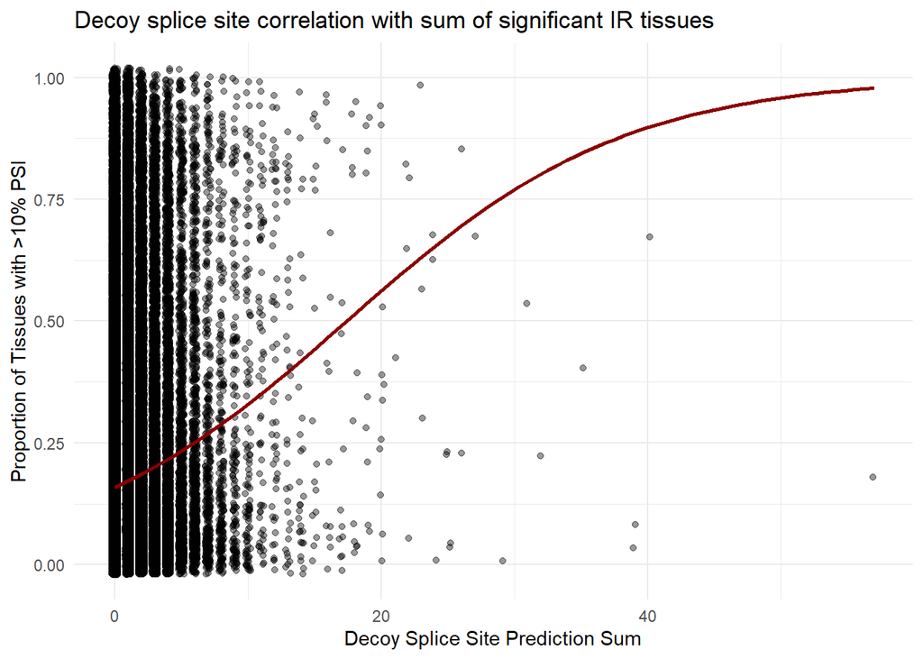

```r
# Define number of trials
merged$failures <- 145 - merged$psi_binarised_total

# Fit binomial logistic regression
fit <- glm(cbind(psi_binarised_total, failures) ~ DecoySiteModerateConf,
           data = merged, family = binomial)

# Create plot
ggplot(merged, aes(x = DecoySiteModerateConf, y = psi_binarised_total / 145)) +
  geom_jitter(width = 0.2, height = 0.02, alpha = 0.4) +
  stat_smooth(method = "glm",
              method.args = list(family = "binomial"),
              aes(weight = 145),
              se = TRUE, colour = "darkred") +
  labs(x = "Decoy Splice Site Prediction Sum",
       y = "Proportion of Tissues with >10% PSI",
       title = "Decoy splice site correlation with sum of significant IR tissues") +
  theme_minimal()
```

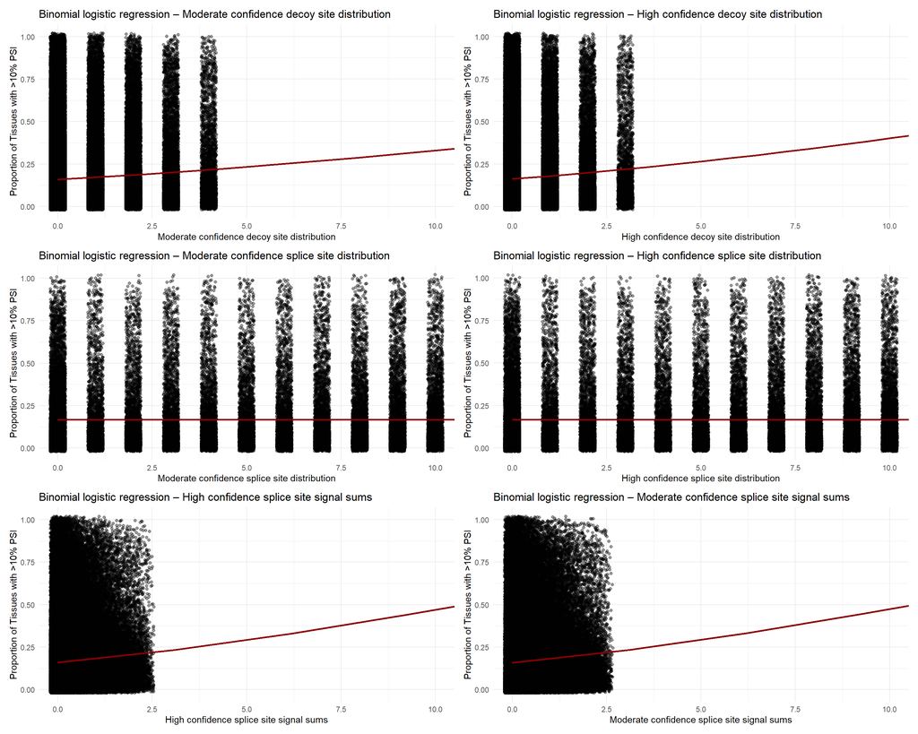

```r
# Predictors to iterate over
predictors <- c("DecoySiteModerateConf", "DecoySiteHighConf",
                "NonPRPF8SpliceCountHighConf", "NonPRPF8SpliceSignalHighConf",
                "NonPRPF8SpliceCountModerateConf", "NonPRPF8SpliceSignalModerateConf")

labels <- c(
  DecoySiteModerateConf   = "Moderate confidence decoy site distribution",
  DecoySiteHighConf    = "High confidence decoy site distribution",
  NonPRPF8SpliceCountModerateConf  = "Moderate confidence splice site distribution",
  NonPRPF8SpliceCountHighConf  = "High confidence splice site distribution",
  NonPRPF8SpliceSignalHighConf    = "High confidence splice site signal sums",
  NonPRPF8SpliceSignalModerateConf    = "Moderate confidence splice site signal sums"
)

# Loop over binomial logistic regression:
plots <- lapply(names(labels), function(var) {

  # Trim jitter points to central 95% interval
  rng <- quantile(merged[[var]], c(0.025, 0.975), na.rm = TRUE)
  df_trim <- merged %>%
    filter(.data[[var]] >= rng[1],
           .data[[var]] <= rng[2])

  ggplot(df_trim, aes_string(x = var, y = "psi_binarised_total / 145")) +
    geom_jitter(width = 0.2, height = 0.02, alpha = 0.4) +
    stat_smooth(data = merged,   # keep model on full dataset
                method = "glm",
                method.args = list(family = "binomial"),
                aes_string(x = var, y = "psi_binarised_total / 145", weight = "145"),
                se = TRUE, level = 0.95, colour = "darkred") +
    labs(x = labels[[var]],
         y = "Proportion of Tissues with >10% PSI",
         title = paste("Binomial logistic regression –", labels[[var]])) +
    theme_minimal() +
    coord_cartesian(xlim = c(0, 10))
})
# Show them in a grid
wrap_plots(plots, ncol = 2)
```

## Calculate association strength with pseudo R^2 to compare predictors combined sums, intron length and cryptic only sums

```r
# --- Binomial GLMs for each predictor (successes vs failures) ---
fit_predict100    <- glm(cbind(psi_binarised_total, 145 - psi_binarised_total) ~ DecoySiteModerateConf,
                         data = merged, family = binomial)
fit_predict50     <- glm(cbind(psi_binarised_total, 145 - psi_binarised_total) ~ DecoySiteHighConf,
                         data = merged, family = binomial)
fit_splice_cnt250 <- glm(cbind(psi_binarised_total, 145 - psi_binarised_total) ~ NonPRPF8SpliceCountHighConf,
                         data = merged, family = binomial)
fit_NonPRPF8SpliceSignalHighConf <- glm(cbind(psi_binarised_total, 145 - psi_binarised_total) ~ NonPRPF8SpliceSignalHighConf,
                         data = merged, family = binomial)
fit_splice_cnt100 <- glm(cbind(psi_binarised_total, 145 - psi_binarised_total) ~ NonPRPF8SpliceCountModerateConf,
                         data = merged, family = binomial)
fit_NonPRPF8SpliceSignalModerateConf <- glm(cbind(psi_binarised_total, 145 - psi_binarised_total) ~ NonPRPF8SpliceSignalModerateConf,
                         data = merged, family = binomial)
fit_length        <- glm(cbind(psi_binarised_total, 145 - psi_binarised_total) ~ LENGTH,
                         data = merged, family = binomial)

# --- McFadden pseudo R^2 using your prior methodology ---
pseudo_r2 <- function(model) {
  1 - (as.numeric(logLik(model)) / as.numeric(logLik(update(model, . ~ 1))))
}

# --- Collect fit stats into a comparison table ---
fits <- list(
  DecoySiteModerateConf   = fit_predict100,
  DecoySiteHighConf    = fit_predict50,
  NonPRPF8SpliceCountHighConf  = fit_splice_cnt250,
  NonPRPF8SpliceSignalHighConf    = fit_NonPRPF8SpliceSignalHighConf,
  NonPRPF8SpliceCountModerateConf  = fit_splice_cnt100,
  NonPRPF8SpliceSignalModerateConf    = fit_NonPRPF8SpliceSignalModerateConf,
  LENGTH           = fit_length
)

comp <- do.call(rbind, lapply(names(fits), function(nm) {
  m <- fits[[nm]]
  data.frame(
    Predictor    = nm,
    McFadden_R2  = round(pseudo_r2(m), 6),
    AIC          = AIC(m),
    LogLik       = round(as.numeric(logLik(m)), 2),
    stringsAsFactors = FALSE
  )
}))

# View table (descending)
comp[order(-comp$McFadden_R2), ]
```

```
##                          Predictor McFadden_R2     AIC   LogLik
## 1            DecoySiteModerateConf    0.009791 7522832 -3761414
## 2                DecoySiteHighConf    0.008425 7533210 -3766603
## 5  NonPRPF8SpliceCountModerateConf    0.000073 7596662 -3798329
## 3      NonPRPF8SpliceCountHighConf    0.000058 7596771 -3798383
## 7                           LENGTH    0.000005 7597176 -3798586
## 6 NonPRPF8SpliceSignalModerateConf   -0.026398 7797765 -3898880
## 4     NonPRPF8SpliceSignalHighConf   -0.027643 7807223 -3903610
```

## Trimming predictors to central 95% and refit analysis shows better fit for nonPRPF8 intronic splice sites and worse fit for decoy sites

```r
# predictors to trim & fit
vars <- c("DecoySiteModerateConf", "DecoySiteHighConf",
          "NonPRPF8SpliceCountHighConf", "NonPRPF8SpliceSignalHighConf",
          "NonPRPF8SpliceCountModerateConf", "NonPRPF8SpliceSignalModerateConf",
          "LENGTH")

comp_trim <- do.call(rbind, lapply(vars, function(v) {
  # trim to central 95% of this predictor
  rng <- quantile(merged[[v]], c(0.025, 0.975), na.rm = TRUE)
  d   <- merged %>% filter(.data[[v]] >= rng[1], .data[[v]] <= rng[2])

  # fit GLM on trimmed data
  fml <- as.formula(paste("cbind(psi_binarised_total, 145 - psi_binarised_total) ~", v))
  m   <- glm(fml, data = d, family = binomial)

  # McFadden pseudo-R2 (inline, no helper)
  r2 <- 1 - (as.numeric(logLik(m)) / as.numeric(logLik(update(m, . ~ 1))))

  data.frame(
    Subset      = "Central 95% of predictor",
    Predictor   = v,
    N           = nrow(d),
    McFadden_R2 = round(r2, 6),
    AIC         = AIC(m),
    LogLik      = as.numeric(logLik(m)),
    stringsAsFactors = FALSE
  )
}))

# view (e.g., sorted by McFadden R2)
comp_trim[order(-comp_trim$McFadden_R2), ]
```

```
##                     Subset                        Predictor      N McFadden_R2
## 1 Central 95% of predictor            DecoySiteModerateConf 189620    0.004889
## 2 Central 95% of predictor                DecoySiteHighConf 190482    0.003962
## 6 Central 95% of predictor NonPRPF8SpliceSignalModerateConf 188127    0.002168
## 5 Central 95% of predictor  NonPRPF8SpliceCountModerateConf 188156    0.002153
## 3 Central 95% of predictor      NonPRPF8SpliceCountHighConf 188127    0.001877
## 4 Central 95% of predictor     NonPRPF8SpliceSignalHighConf 188127    0.001342
## 7 Central 95% of predictor                           LENGTH 183536    0.000027
##       AIC   LogLik
## 1 7316534 -3658265
## 2 7372298 -3686147
## 6 7373186 -3686591
## 5 7419836 -3709916
## 3 7421882 -3710939
## 4 7392817 -3696406
## 7 7260553 -3630275
```

## plot the regression against length to visually compare association strength

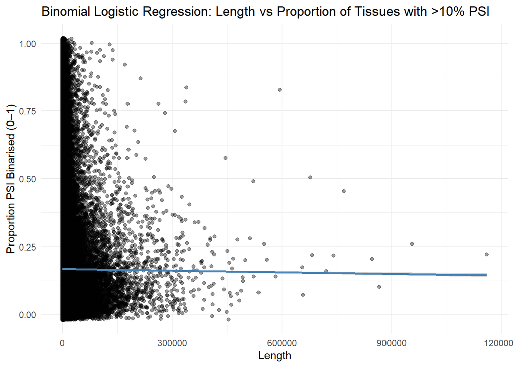

```r
# Plot
ggplot(merged, aes(x = LENGTH, y = psi_binarised_total / 145)) +
  geom_jitter(width = 0.2, height = 0.02, alpha = 0.4) +
  stat_smooth(method = "glm",
              method.args = list(family = "binomial"),
              aes(weight = 145),
              se = TRUE, colour = "steelblue") +
  labs(x = "Length",
       y = "Proportion PSI Binarised (0–1)",
       title = "Binomial Logistic Regression: Length vs Proportion of Tissues with >10% PSI") +
  theme_minimal()
```

## Plot box plots

```r
# --- define the six predictors (no LENGTH) ---
vars <- c(
  "DecoySiteModerateConf",
  "DecoySiteHighConf",
  "NonPRPF8SpliceCountModerateConf",
  "NonPRPF8SpliceCountHighConf",
  "NonPRPF8SpliceSignalHighConf",
  "NonPRPF8SpliceSignalModerateConf"
)

labels <- c(
  DecoySiteModerateConf            = "Moderate confidence decoy site distribution",
  DecoySiteHighConf                = "High confidence decoy site distribution",
  NonPRPF8SpliceCountModerateConf  = "Moderate confidence splice site distribution",
  NonPRPF8SpliceCountHighConf      = "High confidence splice site distribution",
  NonPRPF8SpliceSignalHighConf     = "High confidence splice site signal sums",
  NonPRPF8SpliceSignalModerateConf = "Moderate confidence splice site signal sums"
)

fills <- c(
  DecoySiteModerateConf            = "darkred",
  DecoySiteHighConf                = "darkorange",
  NonPRPF8SpliceCountHighConf      = "navy",
  NonPRPF8SpliceSignalHighConf     = "steelblue",
  NonPRPF8SpliceCountModerateConf  = "darkgreen",
  NonPRPF8SpliceSignalModerateConf = "seagreen"
)

# long format with predictor 'value' and psi
df_long <- merged %>%
  dplyr::select(dplyr::all_of(vars), psi_binarised_total) %>%
  tidyr::pivot_longer(dplyr::all_of(vars), names_to = "variable", values_to = "value") %>%
  dplyr::filter(!is.na(value)) %>%
  dplyr::mutate(
    # thresholds by predictor: drop zeros for counts/decoys; drop <0.02 for signals
    min_threshold = dplyr::case_when(
      variable %in% c("NonPRPF8SpliceSignalHighConf", "NonPRPF8SpliceSignalModerateConf") ~ 0.02,
      TRUE ~ 0
    ),
    var_label = factor(variable, levels = vars, labels = labels[vars])
  )

# prefilter by threshold, then compute per-variable 95% window on the predictor
df_trim <- df_long %>%
  dplyr::group_by(variable) %>%
  dplyr::filter(value > min_threshold) %>%                                       # <- key prefilter
  dplyr::mutate(
    lo = stats::quantile(value, 0.025, na.rm = TRUE),
    hi = stats::quantile(value, 0.975, na.rm = TRUE)
  ) %>%
  dplyr::ungroup() %>%
  dplyr::filter(value >= lo, value <= hi)

# optional: a compact data table describing what was kept per facet
keep_summary <- df_trim %>%
  dplyr::group_by(variable, var_label) %>%
  dplyr::summarise(
    threshold_used = dplyr::first(min_threshold),
    pred_lo = dplyr::first(lo),
    pred_hi = dplyr::first(hi),
    n_rows = dplyr::n(),
    .groups = "drop"
  )
print(keep_summary)
```

```
## # A tibble: 6 × 6
##   variable                       var_label threshold_used pred_lo pred_hi n_rows
##   <chr>                          <fct>              <dbl>   <dbl>   <dbl>  <int>
## 1 DecoySiteHighConf              High con…           0     1         5     34351
## 2 DecoySiteModerateConf          Moderate…           0     1         6     66356
## 3 NonPRPF8SpliceCountHighConf    High con…           0     2       121    172354
## 4 NonPRPF8SpliceCountModerateCo… Moderate…           0     2       121    173408
## 5 NonPRPF8SpliceSignalHighConf   High con…           0.02  0.0258    2.59 148230
## 6 NonPRPF8SpliceSignalModerateC… Moderate…           0.02  0.0270    2.68 151497
```

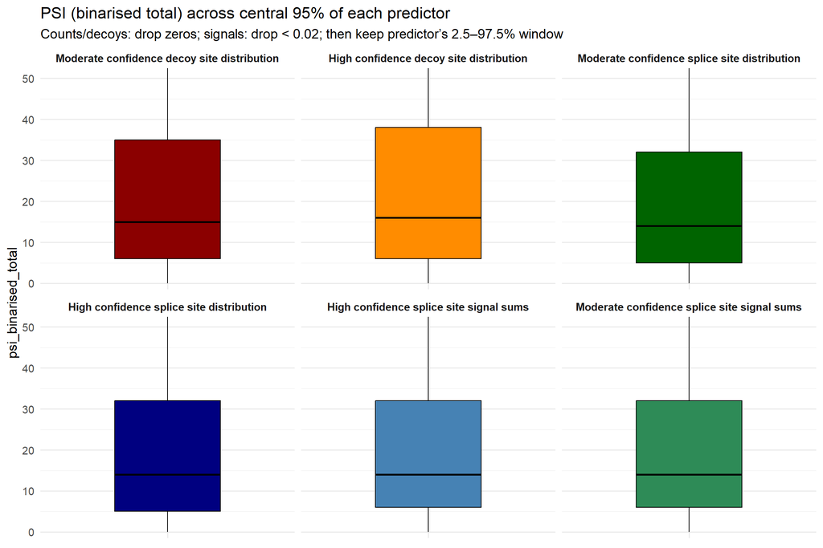

```r
ggplot2::ggplot(df_trim, ggplot2::aes(x = factor(1), y = psi_binarised_total, fill = variable)) +
  ggplot2::geom_boxplot(width = 0.5, colour = "black", outlier.shape = NA) +
  ggplot2::facet_wrap(~ var_label, ncol = 3) +
  ggplot2::coord_cartesian(ylim = c(1, 50)) +   # zooms without recomputing stats
  ggplot2::scale_fill_manual(values = fills, guide = "none") +
  ggplot2::labs(
    title = "PSI (binarised total) across central 95% of each predictor",
    subtitle = "Counts/decoys: drop zeros; signals: drop < 0.02; then keep predictor’s 2.5–97.5% window",
    x = NULL, y = "psi_binarised_total"
  ) +
  ggplot2::theme_minimal(base_size = 14) +
  ggplot2::theme(
    axis.text.x  = ggplot2::element_blank(),
    axis.ticks.x = ggplot2::element_blank(),
    strip.text   = ggplot2::element_text(face = "bold")
  )
```

## Plot length capped at 25kb against cluster identity

[figure not shown]

```r
ggplot(merged, aes(x = factor(Cluster), y = LENGTH, fill = factor(Cluster))) +
    geom_violin(trim = FALSE, scale = "width", colour = "black", alpha = 0.7) +
    geom_boxplot(width = 0.1, outlier.shape = NA, fill = "white", colour = "black") +
    scale_fill_brewer(palette = "Set2", name = "Cluster") +
    labs(
        title = "Intron length does not influence PSI cluster identity",
        x = "Intron retention category",
        y = "Base pair length"
    ) +
    coord_cartesian(ylim = c(0, 25000)) +
    theme_minimal(base_size = 14) +
    theme(legend.position = "none")
```

### OLD SCRIPT BELOW THIS SECTION ###

## Use Genomic Ranges to overlap predictions with introns, summarise number of predictions for each intron

library(GenomicRanges) library(dplyr) library(ggplot2)

## Convert to GRanges

gr_merged <- GRanges(seqnames = merged$chrom, ranges = IRanges(start = merged$start, end = merged$end), strand = merged$strand)

gr_predict100 <- GRanges(seqnames = predict100$V1, ranges = IRanges(start = predict100$V2, end = predict100$V3), strand = predict100$V6)

## Find overlaps

hits <- findOverlaps(gr_merged, gr_predict100, ignore.strand = FALSE)

## Summarise overlaps

summary_df <- as.data.frame(hits) %>% mutate(value = predict100$V7[subjectHits]) %>% group_by(queryHits) %>% summarise(overlap_sum100 = sum(value, na.rm = TRUE), .groups = “drop”)

## Add Moderate Confidence Decoy overlap summary back into merged, preserving all rows

merged$DecoySiteModerateConf <- 0 # default to 0 merged$DecoySiteModerateConf[summary_df$queryHits] <- summary_df$overlap_sum100 merged <- merged %>% relocate(DecoySiteModerateConf, .after = 1) # relocate overlap sum to second col

## repeat this process for predict f50 (High Confidence Decoy)

gr_predict50 <- GRanges(seqnames = predict50$V1, ranges = IRanges(start = predict50$V2, end = predict50$V3), strand = predict50$V6)

## Find overlaps

hits2 <- findOverlaps(gr_merged, gr_predict50, ignore.strand = FALSE)

## Summarise overlaps

summary_df <- as.data.frame(hits2) %>% mutate(value = predict50$V7[subjectHits]) %>% group_by(queryHits) %>% summarise(overlap_sum50 = sum(value, na.rm = TRUE), .groups = “drop”)

## Add overlap summary back into merged, preserving all rows

merged$DecoySiteHighConf <- 0 # default to 0 merged$DecoySiteHighConf[summary_df$queryHits] <- summary_df$overlap_sum50 merged <- merged %>% relocate(DecoySiteHighConf, .after = 2) # relocate overlap sum to second col

# Create an additional GRanges object for cryptic splice predictions that don’t overlap PRPF8 predictions

## Build GRanges for HIGH CONFIDENCE cryptic splice predictions that don’t overlap with PRPF8 predictions

gr_splice250 <- GRanges( seqnames = splice250$V1, ranges = IRanges(start = splice250$V2, end = splice250$V3), strand = splice250$V6 )

## Find overlaps of merged introns vs splice predictions

hits_splice <- findOverlaps(gr_merged, gr_splice250, ignore.strand = FALSE)

## Count one per splice hit, per merged intron

summary_splice_df <- as.data.frame(hits_splice) %>% group_by(queryHits) %>% summarise(NonPRPF8SpliceCountHighConf = n(), .groups = “drop”)

## Add back into merged, defaulting to 0

merged$NonPRPF8SpliceCountHighConf <- 0 merged$NonPRPF8SpliceCountHighConf[ summary_splice_df$queryHits ] <- summary_splice_df$NonPRPF8SpliceCountHighConf

## Relocate for convenience (just after predict_overlap_sum)

merged <- merged %>% relocate(NonPRPF8SpliceCountHighConf, .after = DecoySiteHighConf)

## Check if splice predictions fit better weighted by summing their signal strength

summary_splice_score <- as.data.frame(hits_splice) %>% mutate(score = splice250$V5[subjectHits]) %>% group_by(queryHits) %>% summarise(NonPRPF8SpliceSignalHighConf = sum(score, na.rm = TRUE), .groups = “drop”)

## Inject into merged

merged$NonPRPF8SpliceSignalHighConf <- 0 merged$NonPRPF8SpliceSignalHighConf[summary_splice_score$queryHits] <- summary_splice_score$NonPRPF8SpliceSignalHighConf merged <- merged %>% relocate(NonPRPF8SpliceSignalHighConf, .after = NonPRPF8SpliceCountHighConf)

# REPEAT Build GRanges for Moderate confidence cryptic splice predictions that don’t overlap with PRPF8 predictions

gr_splice100 <- GRanges( seqnames = splice100$V1, ranges = IRanges(start = splice100$V2, end = splice100$V3), strand = splice100$V6 )

## Find overlaps of merged introns vs splice predictions

hits_splice2 <- findOverlaps(gr_merged, gr_splice100, ignore.strand = FALSE)

## Count one per splice hit, per merged intron

summary_splice_df <- as.data.frame(hits_splice2) %>% group_by(queryHits) %>% summarise(NonPRPF8SpliceCountModerateConf = n(), .groups = “drop”)

## Add back into merged, defaulting to 0

merged$NonPRPF8SpliceCountModerateConf <- 0 merged$NonPRPF8SpliceCountModerateConf[ summary_splice_df$queryHits ] <- summary_splice_df$NonPRPF8SpliceCountModerateConf

## Relocate for convenience (just after predict_overlap_sum)

merged <- merged %>% relocate(NonPRPF8SpliceCountModerateConf, .after = NonPRPF8SpliceSignalHighConf)

## Check if splice predictions fit better weighted by summing their signal strength

summary_splice_score <- as.data.frame(hits_splice2) %>% mutate(score = splice100$V5[subjectHits]) %>% group_by(queryHits) %>% summarise(NonPRPF8SpliceCountModerateConf = sum(score, na.rm = TRUE), .groups = “drop”)

## Inject into merged

merged$NonPRPF8SpliceCountModerateConf <- 0 merged$NonPRPF8SpliceCountModerateConf[summary_splice_score$queryHits] <- summary_splice_score$NonPRPF8SpliceCountModerateConf merged <- merged %>% relocate(NonPRPF8SpliceCountModerateConf, .after = NonPRPF8SpliceCountModerateConf)

# Creation of transposable element overrepresentation tables

library(dplyr)

## Define transposon columns by name

transposon_cols <- colnames(merged)[29:37]

## Clean and summarise

summary_table <- merged %>% mutate(across(all_of(transposon_cols), ~ ifelse(is.na(.) | . == ““, 0, 1))) %>% group_by(CLUSTER) %>% summarise(across(all_of(transposon_cols), sum))

## Step 1: Count total entries per CLUSTER

cluster_sizes <- merged %>% group_by(CLUSTER) %>% summarise(cluster_total = n())

## Step 2: Get transposon sums per CLUSTER

transposon_sums <- merged %>% mutate(across(all_of(transposon_cols), ~ ifelse(is.na(.) | . == ““, 0, 1))) %>% group_by(CLUSTER) %>% summarise(across(all_of(transposon_cols), sum, .names =”sum_{.col}“))

## Step 3: Join totals and compute proportions (overrepresentation)

transposon_enrichment <- left_join(transposon_sums, cluster_sizes, by = “CLUSTER”) %>% mutate(across(starts_with(“sum_”), ~ . / cluster_total, .names = “rel_{.col}”))